# Program Evaluation (Causal Inference) 2: Regression Discontinuity Design

Instructor: Yuta Toyama

Last updated: 2020-03-30

# 1 Introduction

## 1.1 Introduction

- Regression Discontinuity Design
  - Exploit the discontinuous change in treatment status to estimate the causal effect.
  - Example:
    - Threshold of test score for college admission
    - Eligibility of policy due to age.
    - Geographic boundary of two regions.
- Pros: Strong internal validity
  - Assumption for identification is weak.
- Cons: Very little external validity
  - What we estimate is the effect on people at the boundary.

## 1.3 Reference

- Angrist and Pischke “Mostly harmless econometrics” Chapter 6
- R packages: https://sites.google.com/site/rdpackages/rdrobust

# 2 Framework

## 2.1 Framework

- $Y_{i}$: observed outcome for person $i$
- Define *potential outcomes*
  - $Y_{1i}$: outcome for $i$ when she is treated (treatment group)
  - $Y_{0i}$: outcome for $i$ when she is not treated (control group)
- $D_{i}$: treatment status is deterministically determined (sharp RD design)
  $$D_{i}=\mathbf{1}\{W_{i}\geq\bar{W}\}$$
  - $W_{i}$: running variable (forcing variable).
  - Probabilistic assignment is allowed (fuzzy RD design)

## 2.2 Example: Incumbent Advantage

- Consider the two-candidate elections
  - $D_{i}$: dummy for incumbent in the election
  - $Y_{i}$: whether the candidate win in the election
  - $W_{i}:$ the vote share in the previous election.
- The incumbent status is defined as
  $$D_{i}=\mathbf{1}\{W_{i}\geq0.5\}$$
- Idea of RD:
  - Suppose that you won with 51%.
  - You are similar to the guy who lose at 49% (main assumption of RD).
  - If you focus on these people, $D_{i}$ is as if it were randomly assigned.

## 2.3 Framework cont.d

- Note that $D_{i}=\mathbf{1}\{W_{i}\geq\bar{W}\}$ implies the unconfoundedness
  $$(Y_{1i},Y_{0i})\perp D_{i}|W_{i}$$
- But the overlap assumption does not hold
  $$P(D_{i}=1|W_{i}=w)=\begin{cases}
  1 & if\ w\geq\bar{W}\\
  0 & if\ w<\bar{W}
  \end{cases}$$
- To compare people with and without treatment, we need to rely on some sort of extrapolation around the threshold.

Linear approach

- Suppose for a moment that
  $$\begin{aligned}
  Y_{1i} & =\rho+Y_{0i}\\
  E[Y_{0i}|W_{i}=w] & =\alpha_{0}+\beta_{0}w\end{aligned}$$
- This leads to a regression
  $$Y_{i}=\alpha+\beta W_{i}+\rho D_{i}+\eta_{i}$$
  - $\rho$ is the causal effect.
- This approach relies on linear extrapolation. May not be good.
  - What if $E[Y_{0i}|W_{i}=w]$ is nonlinear?

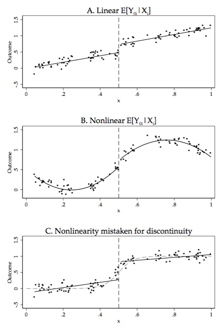

image

## 2.4 A more general approach

- Allowing for nonlinear effect of the running variable $W_{i}$
  $$Y_{i}=f(W_{i})+\rho\mathbf{1}\{W_{i}\geq\bar{W}\}+\eta_{i}$$
- A function $f(\cdot)$ might be a $p$th order polynomial.
  $$f(W_{i})=\beta_{1}W_{i}+\beta_{2}W_{i}^{2}+\cdots+\beta_{p}W_{i}^{p}$$
  - nonparametric approach later.

Implementation in Regression

- Consider
  $$\begin{aligned}
  E[Y_{0i}|W_{i}=w] & =f_{0}(W_{i}-\bar{W})\\
  E[Y_{1i}|W_{i}=w] & =\rho+f_{1}(W_{i}-\bar{W})\end{aligned}$$
  - $\tilde{W}_{i}=W_{i}-\bar{W}$ is a normalization.
- Then the regression equation is (See page 255 in Angrist and Pischke)
  $$\begin{aligned}
  Y_{i} & =\alpha+\beta_{01}\tilde{W_{i}}+\cdots+\beta_{0p}\tilde{W}_{i}^{p}\\
  & +\rho D_{i}+\beta_{1}^{*}D_{i}\tilde{W}_{i}+\cdots+\beta_{p}^{*}D_{i}\tilde{W}_{i}^{p}+\eta_{i}\end{aligned}$$
  - $\rho$ is the causal effect.
- When running regression, need to focus on the sample around threshold.
  - How close the sample should be to the threshold can be taken care by statistical procedure.

# 3 Example

## 3.1 From Mastering Metrics Sec 4.1: Effects of the minimum age drinking law

[figure not shown]

image

[figure not shown]

image

[figure not shown]

image

[figure not shown]

image

# 4 Formal Analysis

## 4.1 Formal Identification Analysis

- Key: continuity assumptions: Both $E[Y_{1i}|W_{i}=w]$ and $E[Y_{0i}|W_{i}=w]$ are continuous at the threshold $w=\bar{W}$.
  - This is not directly testable assumption (because we cannot observe $Y_{1i}$ below the threshold).
  - Will discuss several validating approaches.
- To see how this works, notice that
  $$\begin{aligned}
  E[Y_{i}|W_{i}=w]= & E[Y_{0i}|W_{i}=w]\\
  & +\mathbf{1}\{w\geq\bar{W}\}\left(E[Y_{1i}|W_{i}=w]-E[Y_{0i}|W_{i}=w]\right)\end{aligned}$$
- Taking the limit of $w$ to $\bar{W}$ from above and below
  $$\begin{aligned}
  \lim_{w\uparrow\bar{W}}E[Y_{i}|W_{i} & =w]=\lim_{w\uparrow\bar{W}}E[Y_{0i}|W_{i}=w]=E[Y_{0i}|W_{i}=\bar{W}]\\
  \lim_{w\downarrow\bar{W}}E[Y_{i}|W_{i} & =w]=\lim_{w\downarrow\bar{W}}E[Y_{1i}|W_{i}=w]=E[Y_{1i}|W_{i}=\bar{W}]\end{aligned}$$
  - Notice that we use continuity in the second equalities!
- Remember that
  $$\begin{aligned}
  \lim_{w\uparrow\bar{W}}E[Y_{i}|W_{i} & =w]=\lim_{w\uparrow\bar{W}}E[Y_{0i}|W_{i}=w]=E[Y_{0i}|W_{i}=\bar{W}]\\
  \lim_{w\downarrow\bar{W}}E[Y_{i}|W_{i} & =w]=\lim_{w\downarrow\bar{W}}E[Y_{1i}|W_{i}=w]=E[Y_{1i}|W_{i}=\bar{W}]\end{aligned}$$
- So, we have
  $$E[Y_{1i}-Y_{0i}|W_{i}=\bar{W}]=\lim_{w\downarrow\bar{W}}E[Y_{i}|W_{i}=w]-\lim_{w\uparrow\bar{W}}E[Y_{i}|W_{i}=w]$$
  - LHS: Average treatment effect at the threshold
  - RHS: We can observe from the data.
    - Conditional expectation near the threshold.

## 4.2 Nonparametric Implementation

- Too much details for this course. I will skip.
- The package ’rddrobust" will take care for all the details.

# 5 Validation of Assumptions

## 5.1 Validation of Assumptions

- The key assumptions : Both $E[Y_{1i}|W_{i}=w]$ and $E[Y_{0i}|W_{i}=w]$ are continuous at the threshold $w=\bar{W}$.
- This is not directly testable because we cannot observe $Y_{1i}$ below the threshold.
- There are two common approaches that support this assumption:
  1. Covariate test
  2. Density test (no bunching in the running variable).

## 5.2 Covariate Test

- The underlying idea of RDD: Comparing outcomes right above and right below $\bar{W}$ provides a comparison of treated and control agents who are similar due to the assumed continuity in conditional distributions
- If this is a valid comparison, then we would expect that covariates $X$ also change smoothly as we pass through the threshold.
  - Run the RDD on the covariate $X$.
- If we found the discontinuity, it suggests that the conditional expectation of $Y$ on $W$ may not be continuous either.
- If $X$ has a direct effect on $Y$, the discontinuity in $E[Y_{i}|W]$ at $\bar{W}$ will confound the treatment effect.
- Example:
  - $Y$ hours worked,
  - $D$: older-than-65 discounts,
  - $W$: age, $X$: social security benefit (non-work income)

## 5.3 Density Test, or No Bunching

- There is also a concern about manipulation if agents know about the institutional details
  - For example, if schools scoring lower than w = 50 on standardized tests get labeled as dysfunctional, we might expect a lot of schools to be right above 50
- In this case, we observe a bunching around the threshold.
  - Agents are “manipulating” treatment assignment around the threshold.
  - Density of $W_{i}$ is discontinuous at $\bar{W}$
- We would expect that $E[Y_{1i}|W_{i}=w]$ would be also discontinuous.
- McCrary (2008) suggests a test of the null hypothesis that the density of $W_{i}$ is continuous at $\bar{W}$.
- Note: Bunching itself is an interesting economic phenomenon. It can be used to analyze a different question.

## 5.4 Ito and Sallee (2018, REStat)

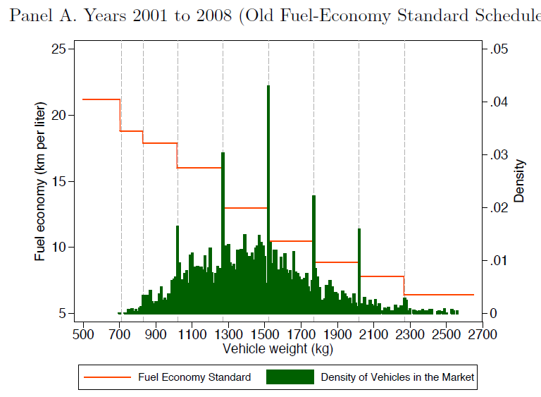

image

## 5.5 Bunching Estimator

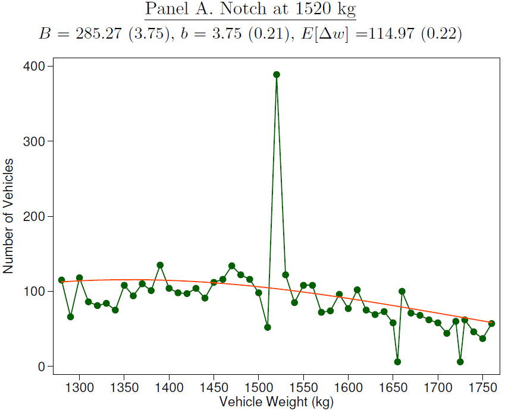

image

- Policy causes excess bunching at 1520.